# BPA/BPS/TCS vs Growth

Main results

M. Rolland

2020-04-10

# 1 Methods

Here we present the preliminary results of the analysis of growth outcomes in link with exposure to Bisphenol A, Bisphenol S and Triclosan during pregnancy.

The growth outcomes at our disposal were:

- Abdominal circumference at the second trimester (T2) and third trimester (T3) of pregnancy
- Femur length at T2 and T3
- Biparietal diameter at T2 and T3
- Head circumference at T2, T3 and birth
- Birth weight
- Birth length

Pregnancy outcomes came from the routine pregnancy ultrasounds and outcomes measured at birth came from the “carnet de santé” filled by the doctor.

When more than one ultrasound was available for an individual at a given trimester only one was kept in order to not over or under estimate some women. The one closest to the median gestational age of the whole cohort for that trimester was kept.

After population, outcome and exposure descriptions and correlations we computed linear regressions between each outcome and exposure at T2 and exposure at T3 separately.

Bisphenol A and Triclosan were log transformed and Bisphenol S was categorised as detected/undetected due to low detection rates.

Missing data were imputed by median for continuous variables and model reference category for categorical variables.

Model covariates were:

- mom age at delivery
- smoking
- maternal education
- child sex
- parity
- pre pregnancy bmi/mom height + weight
- gestational age at outcome measure
- (gestational age at outcome measure)²

Outcomes were standardised (/sd) to make the betas comparable.

# 2 Population flow chart

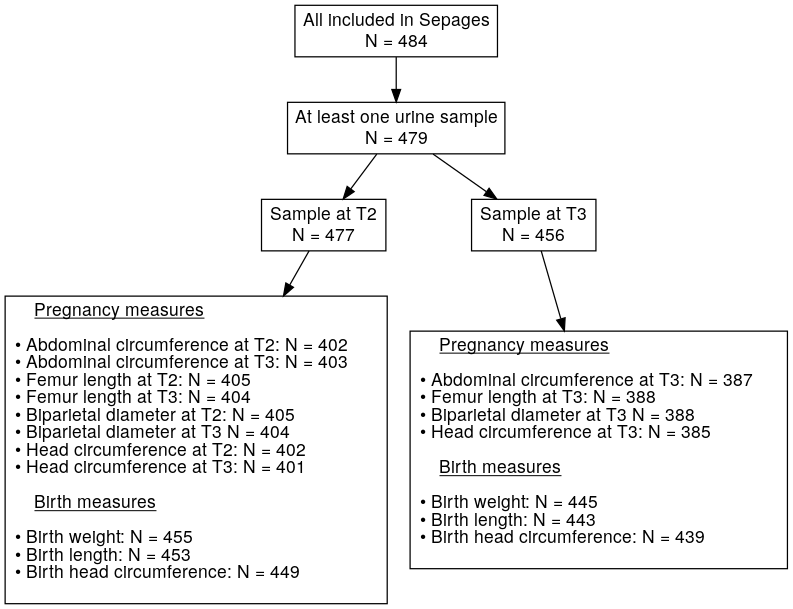

# 3 Population description

|  |  | N | % |
| --- | --- | --- | --- |
| Child sex | Boy | 251 | 52% |
|  | Girl | 218 | 46% |
|  | Missing | 10 | 2% |
| Maternal age | (20,30] | 125 | 26% |
|  | (30,40] | 343 | 72% |
|  | (40,46] | 11 | 2% |
| Maternal BMI | (15,18.5] | 29 | 6% |
|  | (18.5,25] | 361 | 75% |
|  | (25,30] | 65 | 14% |
|  | (30,35] | 12 | 3% |
|  | (35,45] | 8 | 2% |
|  | Missing | 4 | 1% |
| Maternal education | >=Bac +5 | 269 | 56% |
|  | Bac +3-4 | 125 | 26% |
|  | Shorter education | 82 | 17% |
|  | Missing | 3 | 1% |
| Parity | First child | 220 | 46% |
|  | Second child | 211 | 44% |
|  | Third child or more | 48 | 10% |
|  | Missing | / | / |
| Smoked at T2 | No | 427 | 89% |
|  | Yes | 11 | 2% |
|  | Missing | 41 | 9% |

# 4 Exposure description

|  | Second trimester (N = 477) % detected | Second trimester (N = 477) p5 | Second trimester (N = 477) median | Second trimester (N = 477) p95 | Third trimester (N = 456) % detected | Third trimester (N = 456) p5 | Third trimester (N = 456) median | Third trimester (N = 456) p95 |
| --- | --- | --- | --- | --- | --- | --- | --- | --- |
| Bisphenol A | 1.00 | 0.56 | 1.60 | 7.24 | 0.98 | 0.42 | 1.45 | 6.95 |
| Triclosan | 0.98 | 0.22 | 0.92 | 165.16 | 0.98 | 0.20 | 0.87 | 176.13 |
| Bisphenol S | 0.25 | / | / | / | 0.28 | / | / | / |

# 5 Outcome description

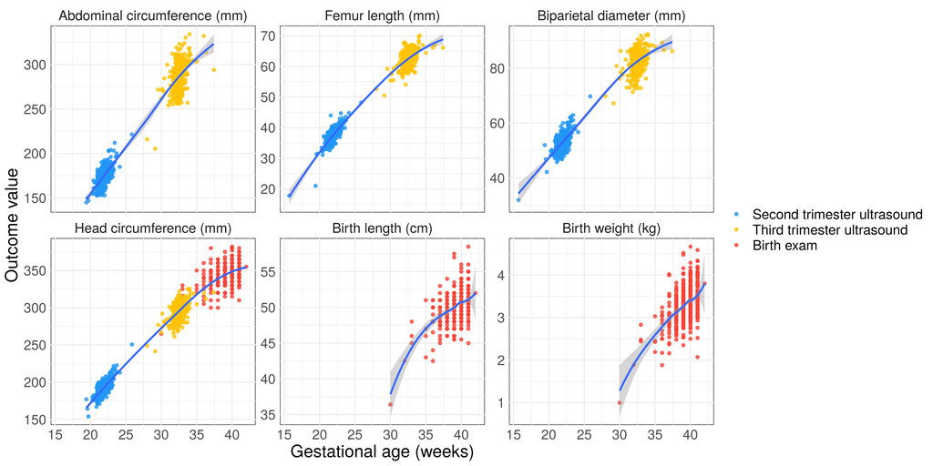

# 6 Correlation between exposures

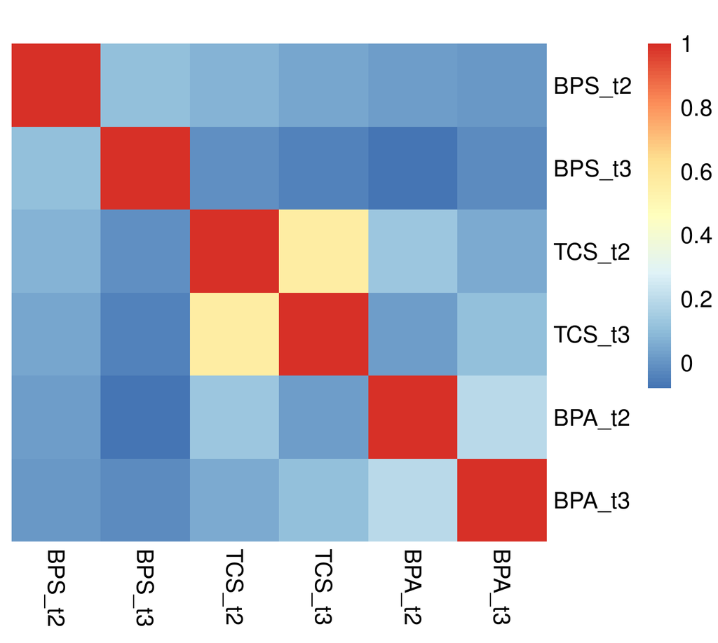

# 7 Correlation between outcomes

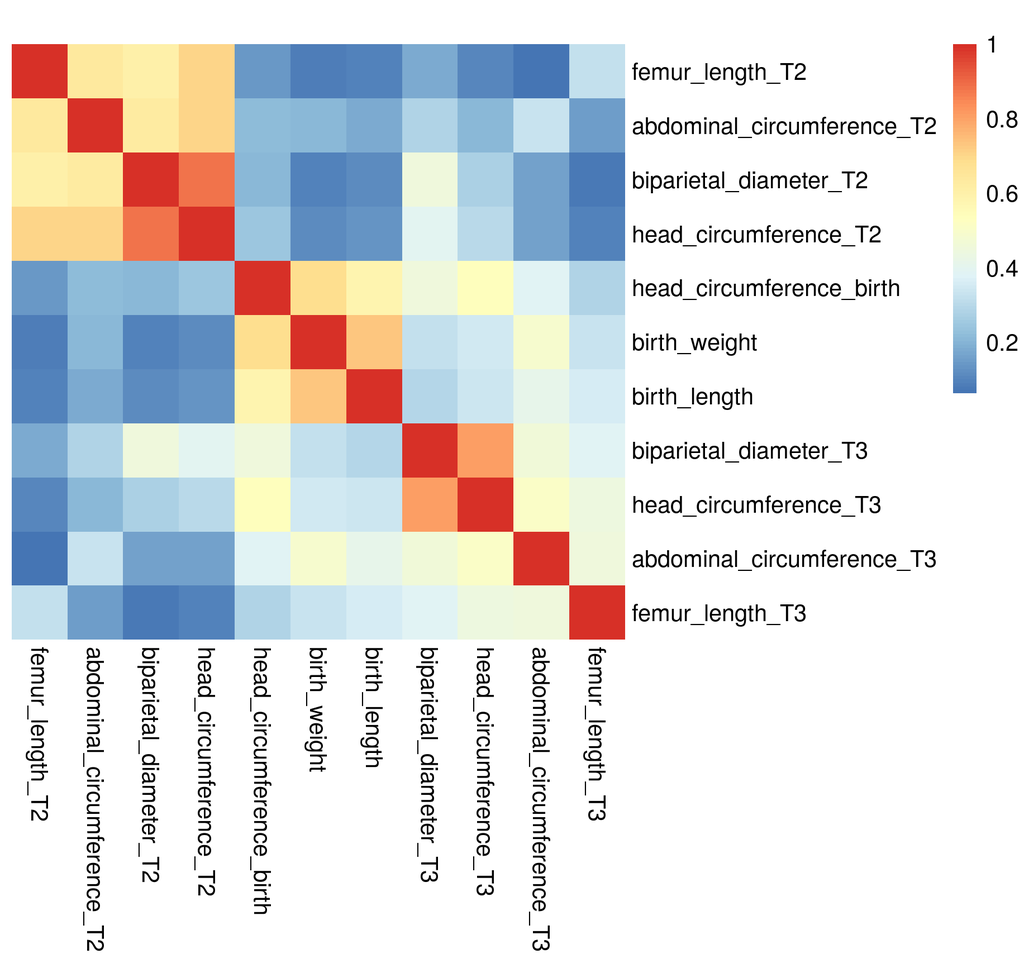

# 8 Multivariate model

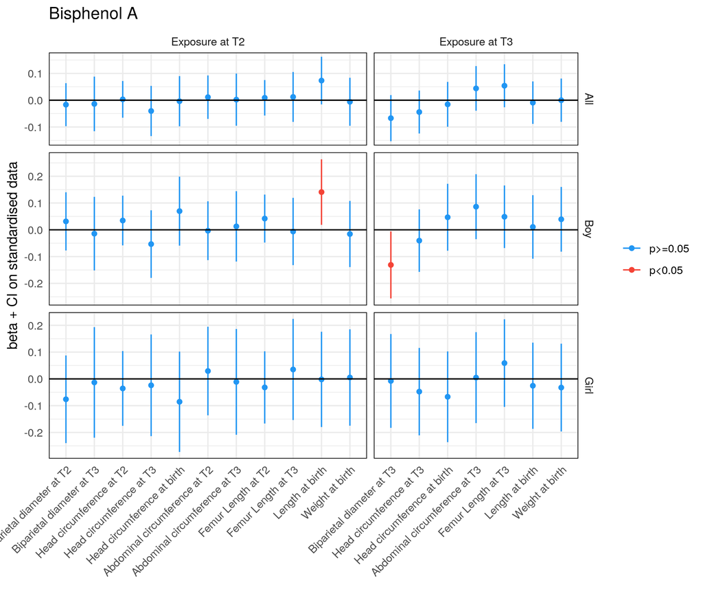

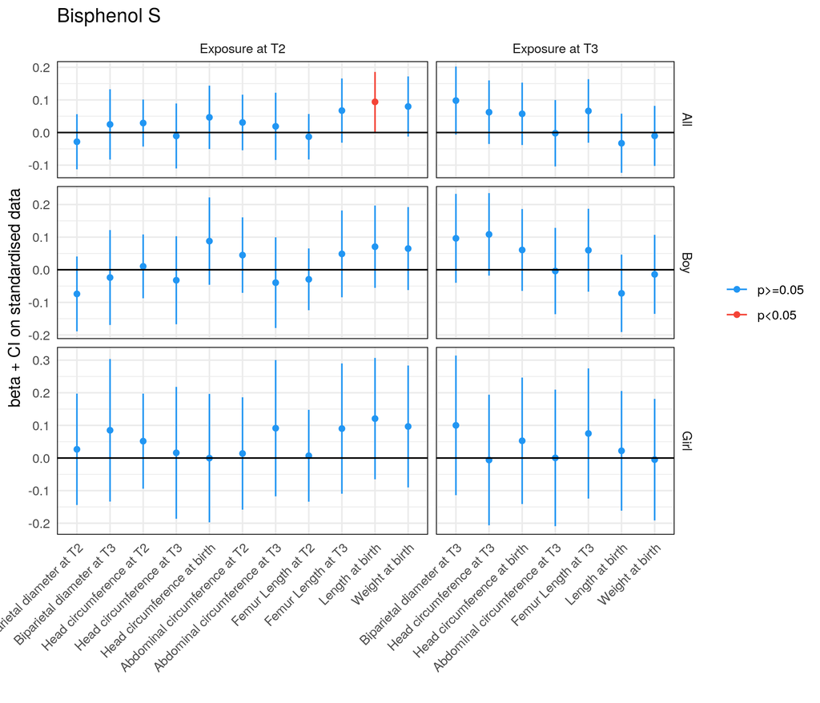

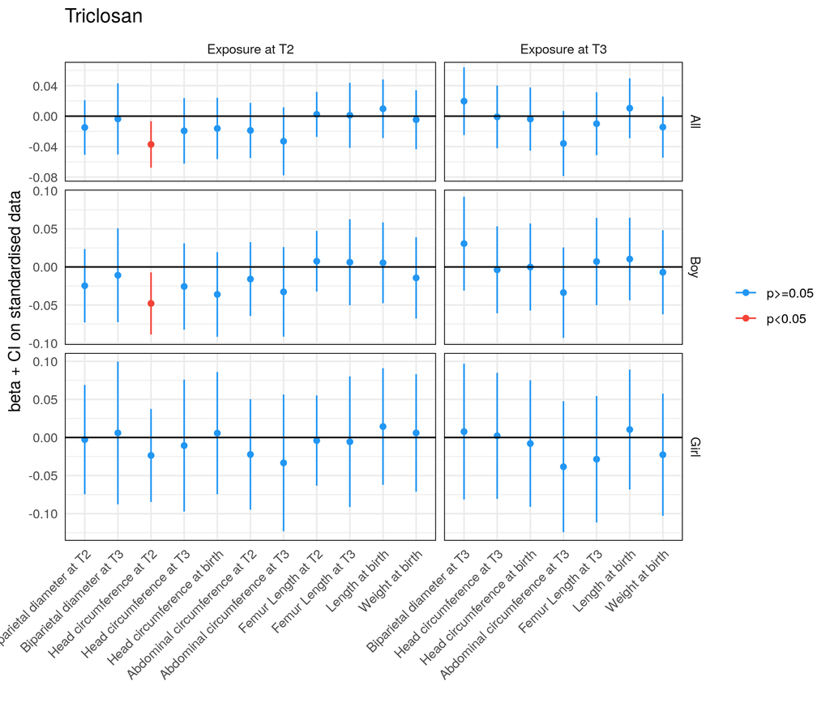